# EDM Lab - WOOD example

Eli Holmes, Eric Ward

25 Feb 2021

Packages

```r
library(ggplot2)
library(atsalibrary)
library(tidyverse)
library(forecast)
library(rEDM)
```

Data

```r
data(sockeye, package="atsalibrary")
dat <- sockeye %>% subset(region=="WOOD" & brood_year>=1960)
endtrain <- 2000
train.idx <- which(dat$brood_year <= endtrain)
test.idx <- which(dat$brood_year > endtrain)
train.year <- dat$brood_year[train.idx]
test.year <- dat$brood_year[test.idx]
```

# Part 1 NN

The forecast for $t$ is the spawners in $t-1$. If this was a good model, then it would be a line where for a given value on the y-axis there would be only one value on the x-axis. It’s a bit of a cloud but let’s use it anyhow.

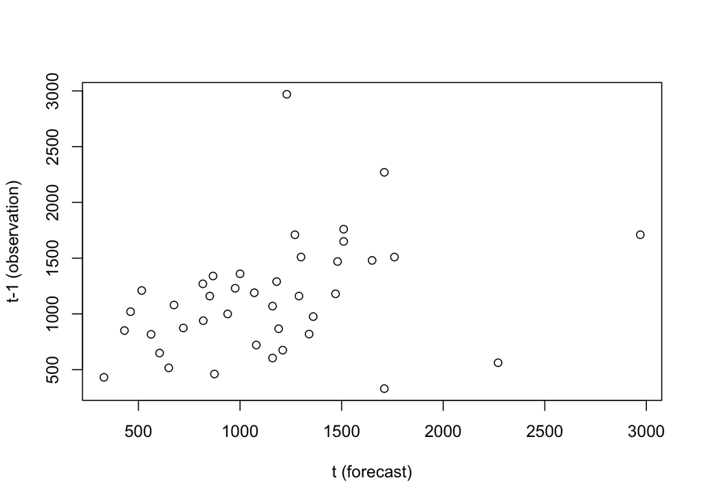

```r
tdat <- subset(dat, brood_year<=endtrain)
n <- nrow(tdat)
plot(tdat$spawners[2:n],
     tdat$spawners[1:(n-1)],
     xlab="t (forecast)", ylab="t-1 (observation)")
```

# Task 1

   ```r
   yr <- 2001
   x <- subset(dat, brood_year==(yr-1))$spawners
   ```

2. Find the 2 years in the training data where spawners are closest to `x`. Since I will need to get the forecasts from my training data, I don’t want to include the last year of the training data $n$. If I did that, then I wouldn’t be able to get the forecast because $n+1$ is not in my training data.

   You can use `sort(..., index.return=TRUE)`.

   ```r
   n <- nrow(tdat)
   idx <- sort(abs(x-tdat$spawners[1:(n-1)]), index.return=TRUE)$ix[1:2]
   tdat$brood_year[idx]
   ```

   ```
   ## [1] 1992 1975
   ```

   ```r
   fc <- mean(tdat$spawners[idx+1])
   fc
   ```

   ```
   ## [1] 998.5
   ```

   I wrote a little function to do my forecast. I pass in the year and it gives me a forecast. It finds the 2 closest years in the training data by using `sort(..., index.return=TRUE)`.

   ```r
   frnn <- function(yr, nn=2){
     x <- subset(dat, brood_year==(yr-1))$spawners
     idx <- sort(abs(x-tdat$spawners[1:(n-1)]), index.return=TRUE)$ix[1:nn]
     fc <- tdat$spawners[idx+1]
     mean(fc)
   }
   ```

The forecast for 2002 is 1565.

# Task 2

Make all my forecasts.

```r
fr <- c()
for (yr in test.year){
  fr <- c(fr, frnn(yr))
}
df <- data.frame(brood_year=(endtrain+1):2005, nn=fr)
df$observed <- dat$spawners[test.idx]
```

Plot the forecasts. Hmm not so good since we have trend in our data.

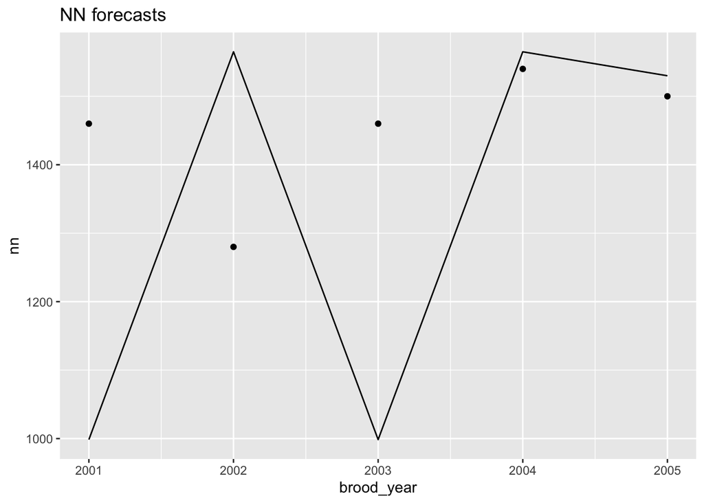

```r
ggplot(df, aes(x=brood_year, y=nn)) + geom_line() +
  geom_point(aes(x=brood_year, y=observed)) +
  ggtitle("NN forecasts")
```

# Task 3

The RMSE for the NN forecasts is

```r
sqrt(mean((df$observed-df$nn)^2))
```

```
## [1] 318.9716
```

## random walk forecasts

Function to get the forecasts

```r
frrw <- function(yr){
  subset(dat, brood_year==(yr-1))$spawners
}
```

Add the RW forecasts to my data frame.

```r
fr <- c()
for (yr in test.year){
  fr <- c(fr, frrw(yr))
}
df$rw <- fr
```

Hmm, the NN forecasts are much worse than my RW forecasts. But my NN strategy was very crude and I didn’t account for the trend in the data. I didn’t even weight by distance.

```r
sqrt(
  c(RW=mean((df$observed-df$rw)^2),
  NN=mean((df$observed-df$nn)^2))
  )
```

```
##       RW       NN
## 140.2854 318.9716
```

Ok that is the idea. Let’s try the EDM algorithm in the rEDM package.

# Part 2 EDM

Empirical dynamic modeling for time series

## Task 1

Use the code on slide 59 to fit the training data `tdat` with the Simplex EDM model.

```r
mod <- rEDM::simplex(as.numeric(tdat$spawners), E=1:10)
```

## Task 2

Let’s use `E=5`.

Correlation plot.

```r
p1 <- ggplot(mod, aes(E,unlist(rho))) +
  geom_line() + theme_bw() + geom_point() +
  xlab("E (lags)") + ylab("rho = cor(obs,pred)")
```

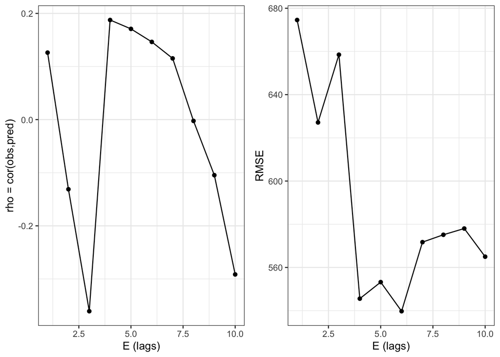

```r
gridExtra::grid.arrange(p1, p2, nrow = 1)
```

## Task 4

Use the code for slide 64 to use data 1960 to 2000 for your library (training data) and data 2001 to 2005 for your prediction (test data).

`lib` is your training data. The function wants the index. But we will leave off the last year in our training data because we need that for our $t+1$ forecast. The function will not return the prediction for the first year of our test data. I will pass in an extra year at the beginning of our test data.

```r
mod <- rEDM::simplex(as.numeric(dat$spawners),
      E=5, stats_only=FALSE,
      lib=c(min(train.idx), max(train.idx)-1),
      pred=c(min(test.idx)-1, max(test.idx)))
```

```r
# get rid of the extra years
pred <- mod$model_output$E5
pred <- pred[pred$Index %in% test.idx,]
# add to my data frame
df$simplex <- pred$Predictions
```

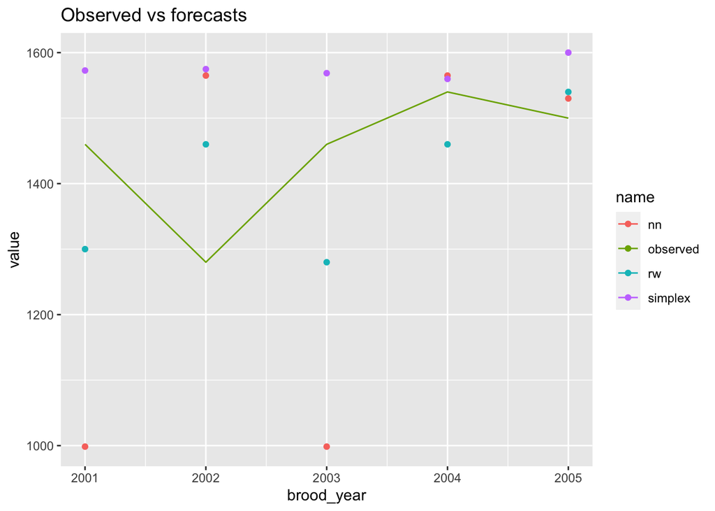

```r
df2 <- pivot_longer(df, cols=-brood_year)
ggplot(subset(df2, name!="observed"), aes(x=brood_year, y=value, col=name)) +
  geom_point() +
  geom_line(data=subset(df2, name=="observed"), aes(x=brood_year, y=value)) +
  ggtitle("Observed vs forecasts")
```

## Task 5

Better! Still not as good as random walk though. But this is a very unfair comparison since the EDM models only get data well in the past and the RW gets last year.

```r
sqrt(
  c(RW=mean((df$observed-df$rw)^2),
  NN=mean((df$observed-df$nn)^2),
  Simplex=mean((df$observed-df$simplex)^2))
)
```

```
##       RW       NN  Simplex
## 140.2854 318.9716 156.0928
```

# Part 3 S-Map

Simplex needs a value for E. I will use `E=5` from the Simplex model.

```r
mod <- rEDM::s_map(as.numeric(tdat$spawners),
                  E=5, stats_only=FALSE)
```

Use the $\theta$ plot to look for non-linearity. There is evidence of non-linearity. Note that $\rho$ is not very big.

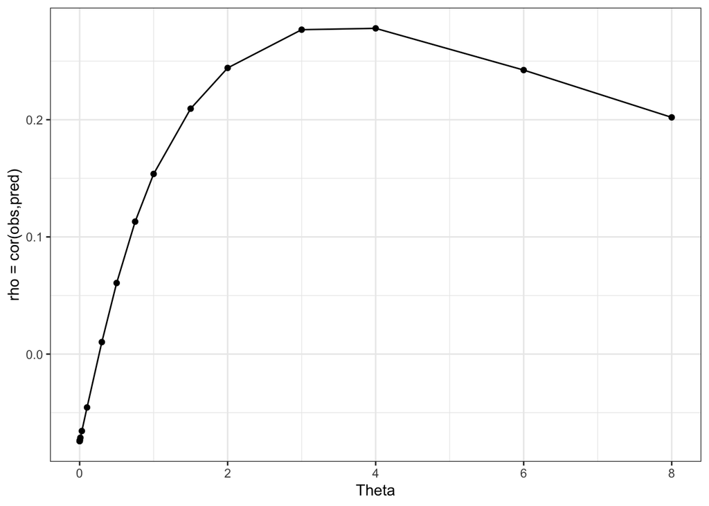

```r
ggplot(mod$stats, aes(theta, unlist(rho))) + geom_line() + geom_point() +
  xlab("Theta") + ylab("rho = cor(obs,pred)") + theme_bw()
```

Let’s modify the code in the lecture to look at other E. It actually looks like E=1 is best.

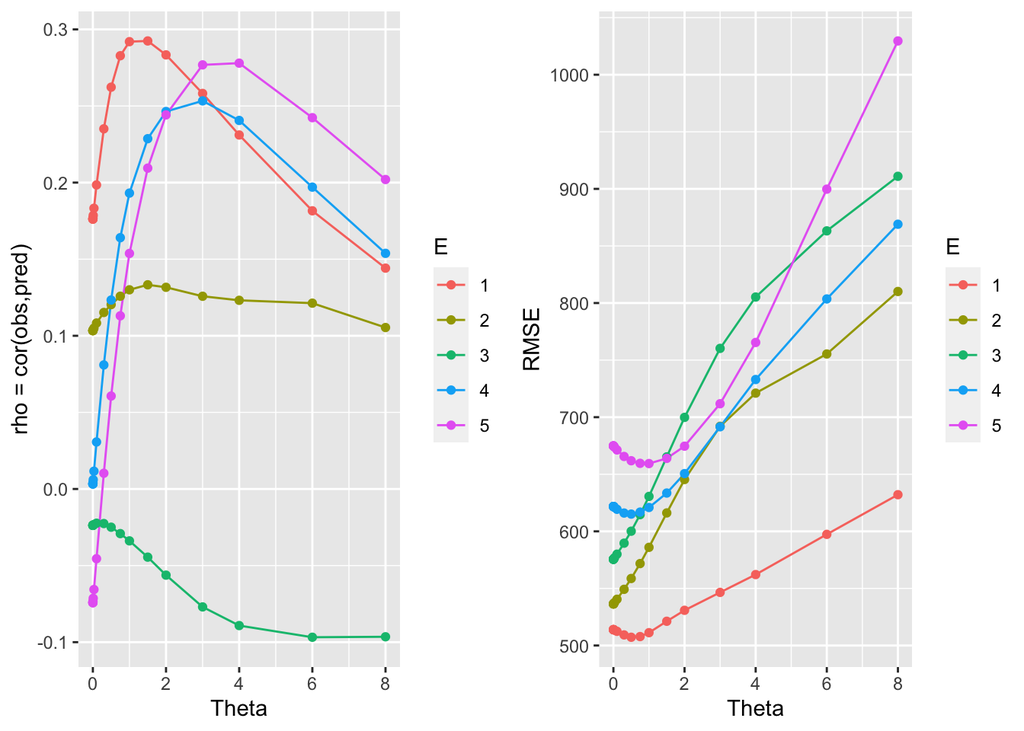

```r
sdat <- as.numeric(tdat$spawners)
mod <- rEDM::s_map(sdat, E=1, stats_only=FALSE)
smap.df <- mod$stats
smap.df$E <- 1

for(i in 2:5) {
  mod <- rEDM::s_map(sdat, E=i, stats_only=FALSE)
  temp <- mod$stats
  temp$E <- i
  smap.df <- rbind(smap.df,temp)
}
smap.df$E <- as.factor(smap.df$E)
p1 <- ggplot(smap.df, aes(theta, unlist(rho), group=E,col=E)) +
  geom_line() + geom_point() +
  xlab("Theta") + ylab("rho = cor(obs,pred)")

p2 <- ggplot(smap.df, aes(theta, unlist(rmse), group=E,col=E)) +
  geom_line() + geom_point() +
  xlab("Theta") + ylab("RMSE")

gridExtra::grid.arrange(p1, p2, nrow=1)
```

## S-Map predictions

We can do predictions in the same way we did with Simplex. I will use `E=1` and `theta=1` here.

```r
mod <- rEDM::s_map(as.numeric(dat$spawners),
      E=1, theta=1, stats_only=FALSE,
      lib=c(min(train.idx), max(train.idx)-1),
      pred=c(min(test.idx)-1, max(test.idx)))
```

Add the predictions to my data frame.

```r
# get rid of the extra years
pred <- mod$model_output$theta1
pred <- pred[pred$Index %in% test.idx,]
# add to my data frame
df$smap <- pred$Predictions
```

Make a plot.

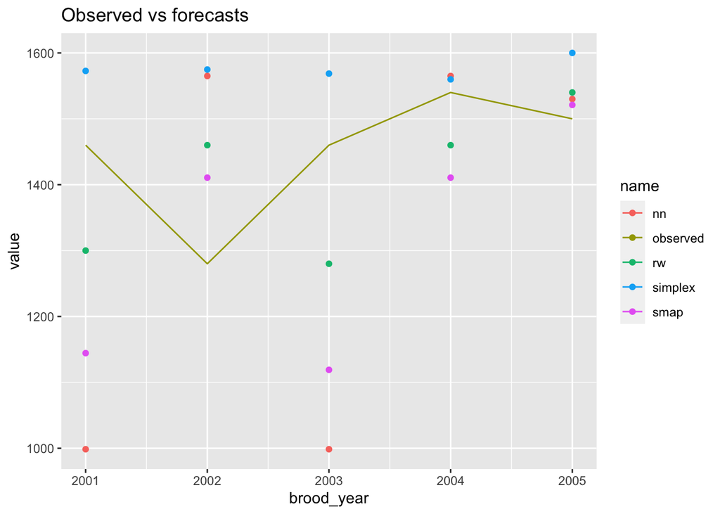

```r
df2 <- pivot_longer(df, cols=-brood_year)
ggplot(subset(df2, name!="observed"), aes(x=brood_year, y=value, col=name)) +
  geom_point() +
  geom_line(data=subset(df2, name=="observed"), aes(x=brood_year, y=value)) +
  ggtitle("Observed vs forecasts")
```

Finally compared the RMSE. S-Map didn’t do so well.

```r
sqrt(
c(RW=mean((df$observed-df$rw)^2),
  NN=mean((df$observed-df$nn)^2),
  Simplex=mean((df$observed-df$simplex)^2),
  SMap.E1=mean((df$observed-df$smap)^2))
)
```

```
##       RW       NN  Simplex  SMap.E1
## 140.2854 318.9716 156.0928 223.6768
```

I will look at various E and $\theta$ and compare the RMSE for the predictions. It looks like for the predictions E=5, $\theta=2$ is good.

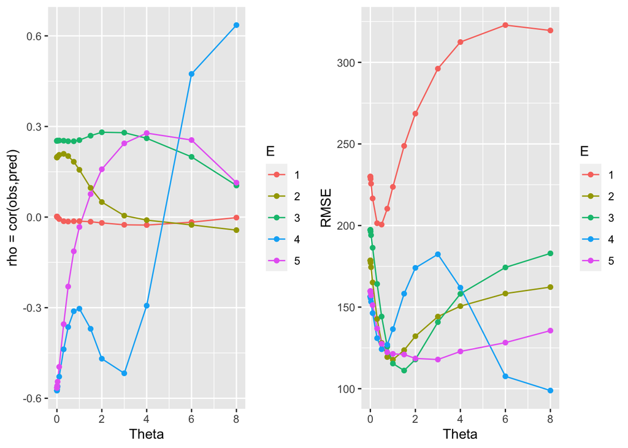

```r
sdat <- dat$spawners
mod <- rEDM::s_map(sdat,
      E=1, stats_only=FALSE,
      lib=c(min(train.idx), max(train.idx)-1),
      pred=c(min(test.idx)-1, max(test.idx)))
smap.df <- mod$stats
smap.df$E <- 1

for(i in 2:5) {
  mod <- rEDM::s_map(sdat,
      E=i, stats_only=FALSE,
      lib=c(min(train.idx), max(train.idx)-1),
      pred=c(min(test.idx)-1, max(test.idx)))
  temp <- mod$stats
  temp$E <- i
  smap.df <- rbind(smap.df,temp)
}
smap.df$E <- as.factor(smap.df$E)
p1 <- ggplot(smap.df, aes(theta, unlist(rho), group=E,col=E)) +
  geom_line() + geom_point() +
  xlab("Theta") + ylab("rho = cor(obs,pred)")

p2 <- ggplot(smap.df, aes(theta, unlist(rmse), group=E,col=E)) +
  geom_line() + geom_point() +
  xlab("Theta") + ylab("RMSE")

gridExtra::grid.arrange(p1, p2, nrow=1)
```

I will add that to the model.

```r
mod <- rEDM::s_map(as.numeric(dat$spawners),
      E=5, theta=2, stats_only=FALSE,
      lib=c(min(train.idx), max(train.idx)-1),
      pred=c(min(test.idx)-1, max(test.idx)))
pred <- mod$model_output$theta2
pred <- pred[pred$Index %in% test.idx,]
# add to my data frame
df$smap2 <- pred$Predictions
```

That was data-dredging on my part to pick the model based on how it performed in the test data. But the best S-Map model did perform best. Note, I didn’t try the same thing with the Simplex data however.

```r
sqrt(
c(RW=mean((df$observed-df$rw)^2),
  NN=mean((df$observed-df$nn)^2),
  Simplex=mean((df$observed-df$simplex)^2),
  SMap.E1=mean((df$observed-df$smap)^2),
  SMap.E15=mean((df$observed-df$smap2)^2))
)
```

```
##       RW       NN  Simplex  SMap.E1 SMap.E15
## 140.2854 318.9716 156.0928 223.6768 118.5397
```

# Summary. Compare to ARIMA

As an experiment, I will try an ARIMA model.

```r
testdat <- dat[test.idx,]
mod <- forecast::auto.arima(as.numeric(tdat$spawners))
pred <- forecast::forecast(mod, h=5)
df$arima <- as.data.frame(pred)[,1]
```

Best model selected by `auto.arima` is a random walk with autocorrelated error (ARIMA(0,1,1)). That model is considerably better than the others even though for the forecast I did not use the test data at all. The forecast is just 5 years past the training data.

```r
sqrt(
c(RW=mean((df$observed-df$rw)^2),
  NN=mean((df$observed-df$nn)^2),
  Simplex=mean((df$observed-df$simplex)^2),
  SMap.E1=mean((df$observed-df$smap)^2),
  SMap.E15=mean((df$observed-df$smap2)^2),
  ARIMA=mean((df$observed-df$arima)^2))
)
```

```
##       RW       NN  Simplex  SMap.E1 SMap.E15    ARIMA
## 140.2854 318.9716 156.0928 223.6768 118.5397  90.0254
```